# Assumptions of Linear Regression

Jasmine Dumas

August 30, 2016

### Requirements

- Linear Regression needs at least two variables
- The amount of samples is preferred to be at minimum 20 observations per variable to have confidence in the model

### 1. Linear Relationship

- The relationship between the independent variable (response) and the dependent variable(s) (predictors) needs to be linear
- Limit the amount of outliers as Linear Regression is sensitive to outliers - test with scatter plots
- R methods: scatter plots

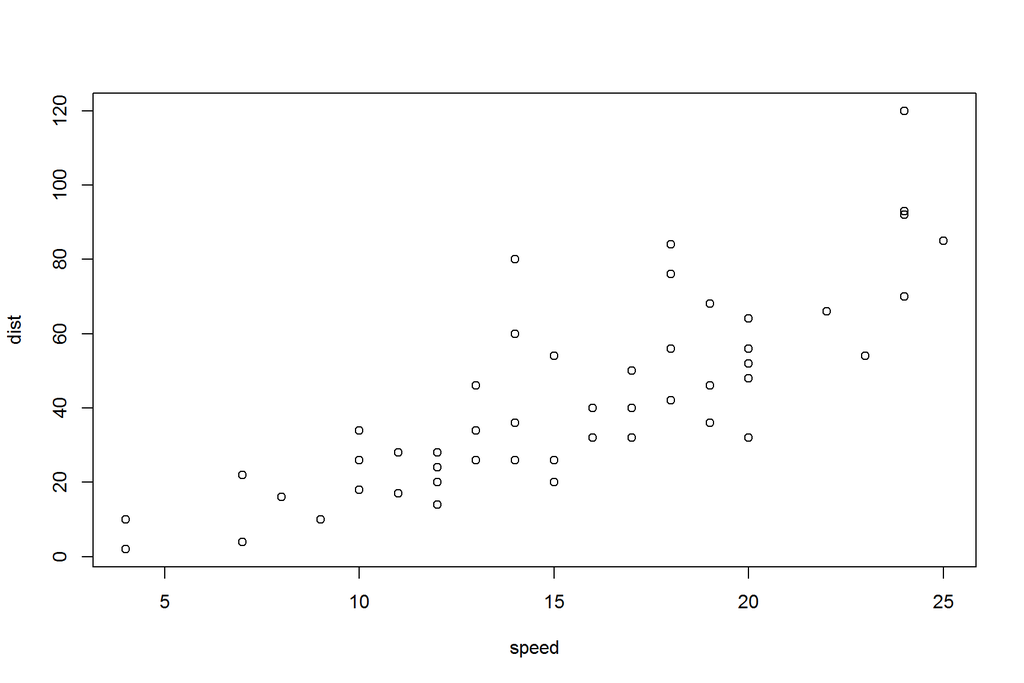

```r
plot(cars)
```

### 2. Multivariate Normality

- The distribution of each of the variables is [normal (or Gaussian)](https://en.wikipedia.org/wiki/Normal_distribution) - the averages of each **random, independent** observations converge (tend towards) a central mean.
- R methods: Histograms, [Shapiro-Wilk Test](https://en.wikipedia.org/wiki/Shapiro%E2%80%93Wilk_test), Q-Q plot, Kolmogorov-Smirnof test

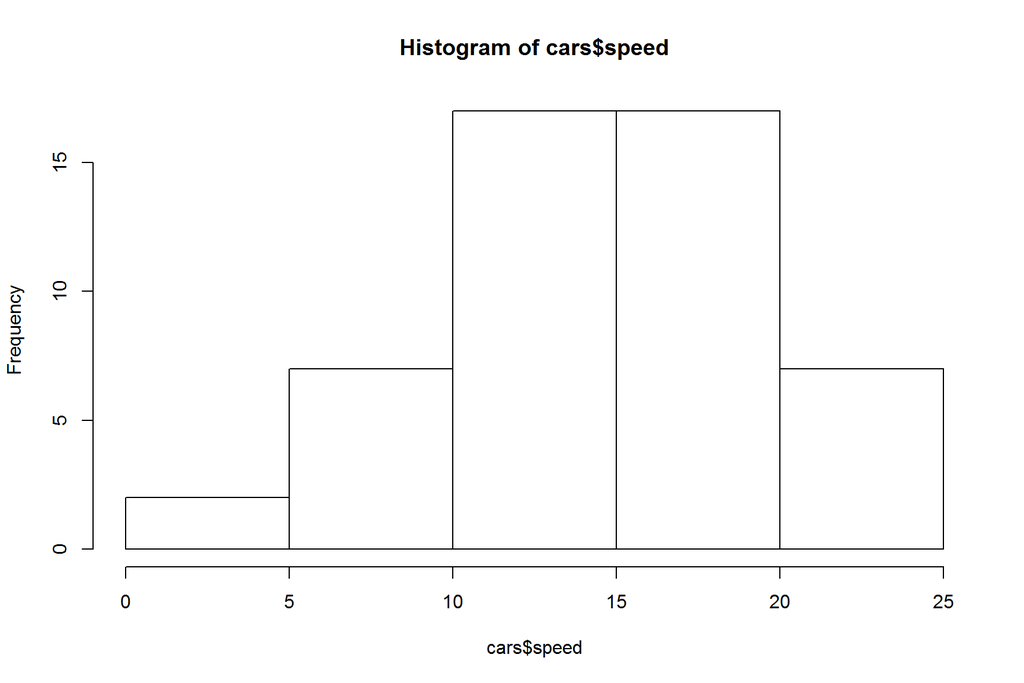

```r
hist(cars$speed)
```

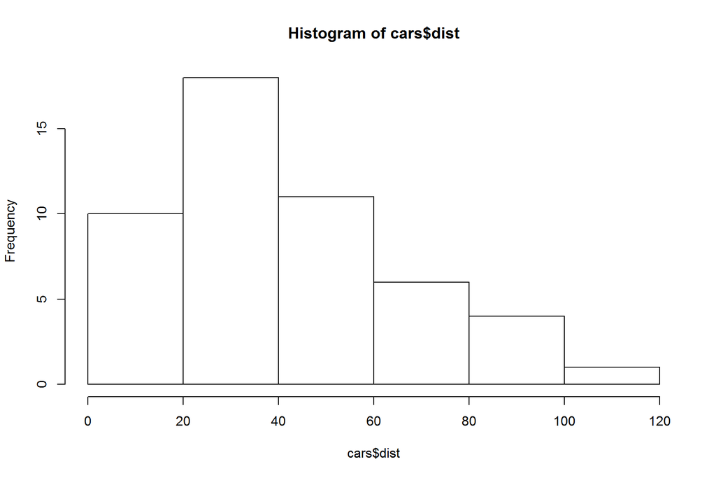

```r
hist(cars$dist)
```

```r
shapiro.test(cars$speed)
```

```
##
##  Shapiro-Wilk normality test
##
## data:  cars$speed
## W = 0.97765, p-value = 0.4576
```

```r
shapiro.test(cars$dist)
```

```
##
##  Shapiro-Wilk normality test
##
## data:  cars$dist
## W = 0.95144, p-value = 0.0391
```

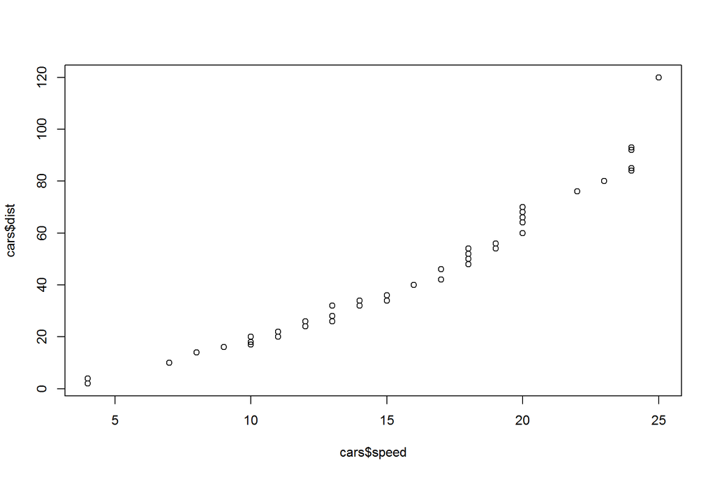

```r
qqplot(cars$speed, cars$dist)
```

```r
ks.test(cars$speed, cars$dist)
```

```
##
##  Two-sample Kolmogorov-Smirnov test
##
## data:  cars$speed and cars$dist
## D = 0.76, p-value = 5.735e-13
## alternative hypothesis: two-sided
```

### 3. No or little multicollinearity

- Multicollinearity occurs when the independent variables are not independent from each other - One variable can be a predictor of the other
- A second important independence assumption is that the error of the mean has to be independent from the independent variables.
- R methods: correlation, tolerance, variance inflation factor (VIF)

```r
cor(cars)
```

```
##           speed      dist
## speed 1.0000000 0.8068949
## dist  0.8068949 1.0000000
```

```r
# example of correlated variables
cars2 <- cars
cars2$speed2 <- cars2$speed
cor(cars2) # if there is a 1.0 in any other position than the diagonal there is perfect correlation
```

```
##            speed      dist    speed2
## speed  1.0000000 0.8068949 1.0000000
## dist   0.8068949 1.0000000 0.8068949
## speed2 1.0000000 0.8068949 1.0000000
```

### 4. No auto-correlation

- Autocorrelation occurs when the residuals are not independent from each other
- correlation of a signal with itself at different points in time - common in *time series analysis*
- R methods: [Durbin-Watson Test](https://en.wikipedia.org/wiki/Durbin%E2%80%93Watson_statistic)

```r
library(car)

fit <- lm(dist ~ speed, data=cars)
summary(fit)
```

```
##
## Call:
## lm(formula = dist ~ speed, data = cars)
##
## Residuals:
##     Min      1Q  Median      3Q     Max
## -29.069  -9.525  -2.272   9.215  43.201
##
## Coefficients:
##             Estimate Std. Error t value Pr(>|t|)
## (Intercept) -17.5791     6.7584  -2.601   0.0123 *
## speed         3.9324     0.4155   9.464 1.49e-12 ***
## ---
## Signif. codes:  0 '***' 0.001 '**' 0.01 '*' 0.05 '.' 0.1 ' ' 1
##
## Residual standard error: 15.38 on 48 degrees of freedom
## Multiple R-squared:  0.6511, Adjusted R-squared:  0.6438
## F-statistic: 89.57 on 1 and 48 DF,  p-value: 1.49e-12
```

```r
durbinWatsonTest(fit)
```

```
##  lag Autocorrelation D-W Statistic p-value
##    1       0.1604322      1.676225   0.166
##  Alternative hypothesis: rho != 0
```

### 5. Homoscedasticity

- The error terms along the regression are the **same** and not heteroscedastic.
- R methods: Residual plot, [Goldfeld-Quandt Test](https://en.wikipedia.org/wiki/Goldfeld%E2%80%93Quandt_test)

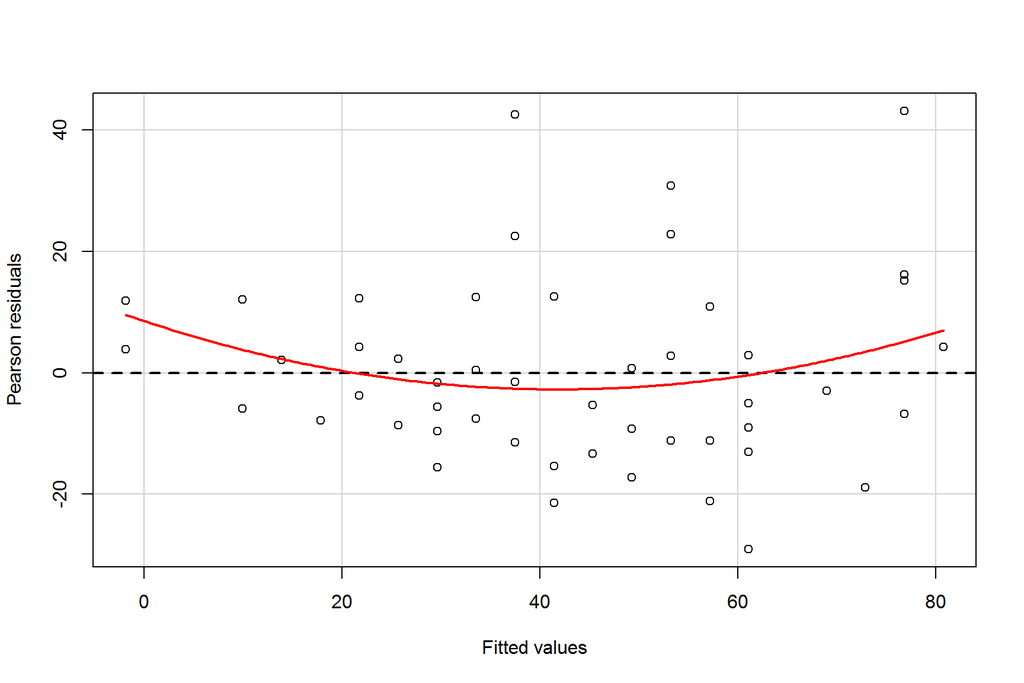

```r
library(car)
residualPlot(fit)
```

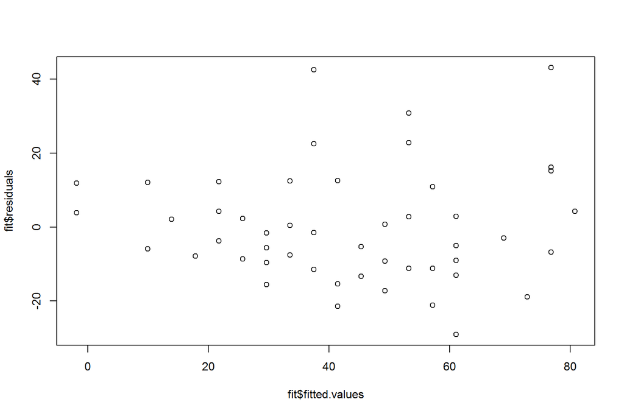

```r
# or in base
plot(fit$fitted.values, fit$residuals)
```

### Resources

- [Statistics Solutions](http://www.statisticssolutions.com/assumptions-of-linear-regression/)
- [Quick R: Diagnostics](http://www.statmethods.net/stats/rdiagnostics.html)
- [Quick R: Probability](http://www.statmethods.net/advgraphs/probability.html)